# Habermans_Survival_Dataset_EDA

## Haberman's Survival Data Set

### By Himanshu Sharma (himanshurkk@gmail.com)

### Introduction

The dataset contains cases from a study that was conducted between 1958 and 1970 at the University of Chicago's Billings Hospital on the survival of patients who had undergone surgery for breast cancer.

### Attribute Information:

- age: Age of patient at time of operation (numerical)
- op_year: Patient's year of operation (year - 1900, numerical)
- axil_nodes: Number of positive axillary nodes detected (numerical)
- surv_status: Survival status (class attribute) 1 = the patient survived 5 years or longer 2 = the patient died within 5 year

```python
# import all packages and set plots to be embedded inline
import numpy as np
import pandas as pd
import matplotlib.pyplot as plt
import seaborn as sns

%matplotlib inline

import warnings
warnings.filterwarnings("ignore")
```

```python
# Read the file and showing the first five rows of the newly combined dataset
df = pd.read_csv('haberman.csv', header=None, names=['age', 'op_year', 'axil_nodes', 'surv_status'])
df.head()
```

|  | age | op_year | axil_nodes | surv_status |
| --- | --- | --- | --- | --- |
| 0 | 30 | 64 | 1 | 1 |
| 1 | 30 | 62 | 3 | 1 |
| 2 | 30 | 65 | 0 | 1 |
| 3 | 31 | 59 | 2 | 1 |
| 4 | 31 | 65 | 4 | 1 |

```python
# check the number of rows and columns
df.shape
```

```
(306, 4)
```

```python
#the data's basic information
df.info(null_counts = True)
```

```
<class 'pandas.core.frame.DataFrame'>
RangeIndex: 306 entries, 0 to 305
Data columns (total 4 columns):
 #   Column       Non-Null Count  Dtype
---  ------       --------------  -----
 0   age          306 non-null    int64
 1   op_year      306 non-null    int64
 2   axil_nodes   306 non-null    int64
 3   surv_status  306 non-null    int64
dtypes: int64(4)
memory usage: 9.7 KB
```

1. In the data, no missing values are present
2. sur_status need to be categorical and instead of numerical(1 and 2) it would be Yes and No.

```python
# modify the target column values to be meaningful as well as categorical
df.surv_status.replace({1: "Yes", 2: "No"}, inplace = True)
```

```python
df.info()
```

```
<class 'pandas.core.frame.DataFrame'>
RangeIndex: 306 entries, 0 to 305
Data columns (total 4 columns):
 #   Column       Non-Null Count  Dtype
---  ------       --------------  -----
 0   age          306 non-null    int64
 1   op_year      306 non-null    int64
 2   axil_nodes   306 non-null    int64
 3   surv_status  306 non-null    object
dtypes: int64(3), object(1)
memory usage: 9.7+ KB
```

```python
df.describe()
```

|  | age | op_year | axil_nodes |
| --- | --- | --- | --- |
| count | 306.000000 | 306.000000 | 306.000000 |
| mean | 52.457516 | 62.852941 | 4.026144 |
| std | 10.803452 | 3.249405 | 7.189654 |
| min | 30.000000 | 58.000000 | 0.000000 |
| 25% | 44.000000 | 60.000000 | 0.000000 |
| 50% | 52.000000 | 63.000000 | 1.000000 |
| 75% | 60.750000 | 65.750000 | 4.000000 |
| max | 83.000000 | 69.000000 | 52.000000 |

```python
df.surv_status.value_counts(normalize = True)*100
```

```
Yes    73.529412
No     26.470588
Name: surv_status, dtype: float64
```

The above result shows that:

```
1. 73.52% people survived 5 years or more than 5 years after operation.
2. 26.47% people survived less tahn 5 years after operation.
3. It is an imbalanced dataset
```

## Univariate Analysis: PDF, CDF, Histogram

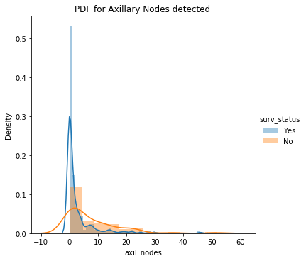

```python
# PDF (probability Distribution Function)
sns.FacetGrid(df, hue="surv_status", size=5).map(sns.distplot, "axil_nodes").add_legend();
plt.title("PDF for Axillary Nodes detected ")
plt.ylabel("Density")
plt.show();
```

- We can observe that as the no. of axillary nodes increase, the chance of survival decreases.

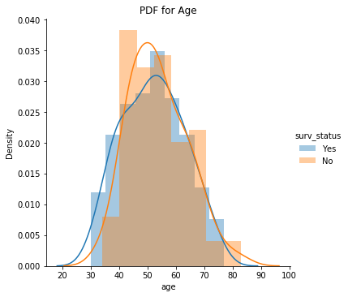

```python
sns.FacetGrid(df, hue="surv_status", size=5).map(sns.distplot, "age").add_legend();
plt.title("PDF for Age")
plt.ylabel("Density")
plt.show();
```

1. Points are overlapping that's why we can say that age has no clear relation b/w age and survival.
2. Patients from age 30 to 34 have higher surival.
3. Patients rom age 78 to 82 have not survived more than 5 years after operation.

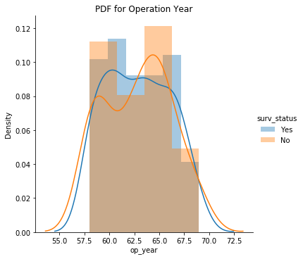

```python
sns.FacetGrid(df, hue="surv_status", size=5).map(sns.distplot, "op_year").add_legend();
plt.title("PDF for Operation Year")
plt.ylabel("Density")
plt.show();
```

- very much overlapping in data pointsso we can not obeserve much sense out of it.

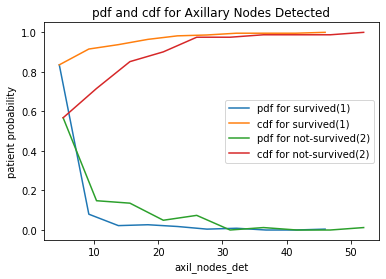

```python
#  Cumulative Distribution Function (CDF) for Axillary Nodes

df_surv=df[df['surv_status']=='Yes']
df_died=df[df['surv_status']=='No']

labels= ["pdf for survived(1)","cdf for survived(1)","pdf for not-survived(2)","cdf for not-survived(2)"]
counts, bin_edges = np.histogram(df_surv["axil_nodes"], bins=10,
                                 density = True)
pdf = counts/(sum(counts))
cdf = np.cumsum(pdf)
plt.plot(bin_edges[1:],pdf);
plt.plot(bin_edges[1:], cdf)


counts, bin_edges = np.histogram(df_died["axil_nodes"], bins=10,
                                 density = True)
pdf = counts/(sum(counts))
cdf = np.cumsum(pdf)
plt.plot(bin_edges[1:],pdf);
plt.plot(bin_edges[1:], cdf)

plt.title("pdf and cdf for Axillary Nodes Detected")
plt.xlabel("axil_nodes_det")
plt.ylabel("patient probability")
plt.legend(labels)

plt.show();
```

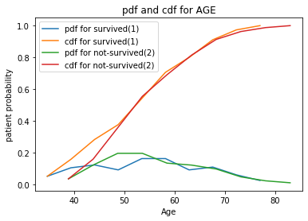

```python
#Cumulative Distribution Function (CDF) for AGE

counts, bin_edges = np.histogram(df_surv["age"], bins=10,density = True)
pdf = counts/(sum(counts))
cdf = np.cumsum(pdf)
plt.plot(bin_edges[1:],pdf)
plt.plot(bin_edges[1:], cdf)


# haberman 2
counts, bin_edges = np.histogram(df_died["age"], bins=10,density = True)
pdf = counts/(sum(counts))
cdf = np.cumsum(pdf)
plt.plot(bin_edges[1:],pdf)
plt.plot(bin_edges[1:], cdf)

plt.title("pdf and cdf for AGE")
plt.xlabel("Age")
plt.ylabel("patient probability")
plt.legend(labels)

plt.show();
```

### oberservation using mean

```python
print(np.mean(df_surv))
```

```
age           52.017778
op_year       62.862222
axil_nodes     2.791111
dtype: float64
```

```python
print(np.mean(df_died))
```

```
age           53.679012
op_year       62.827160
axil_nodes     7.456790
dtype: float64
```

### Box Plot

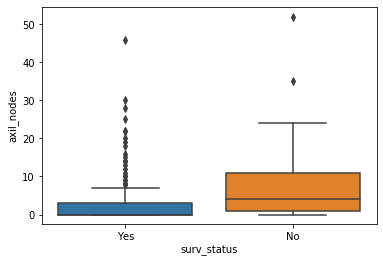

```python
sns.boxplot(x='surv_status',y='axil_nodes', data=df)
plt.show()
```

- For patients who survived the boxplot for axilary nodes detected showed that the 25th and 50th percentiles are overlapped and 75th percentile value is nearly 3.
- Also we can see that there are many outliers of axillary nodes detected for people who survived.
- For people who didn't survive 25th percentile of axillary nodes detected is 1 , 50th percentile is 4 and 75th percentile is 11.
- There are very few outliers of axillary nodes detected for people who didn't survived.

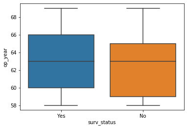

```python
sns.boxplot(x='surv_status',y='op_year', data=df)
plt.show()
```

- As the year increased, percentile of patients surviving the opertaion also increased.
- 75th percentile of Op_Year of people who survived is 1966, and 75th percentile of people wo didn't survive is 1965.
- 25th percentile of Op_Year of people who survived is 1960, and 75th percentile of people wo didn't survive is 1959.

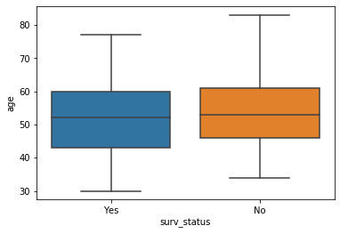

```python
sns.boxplot(x='surv_status',y='age', data=df)
plt.show()
```

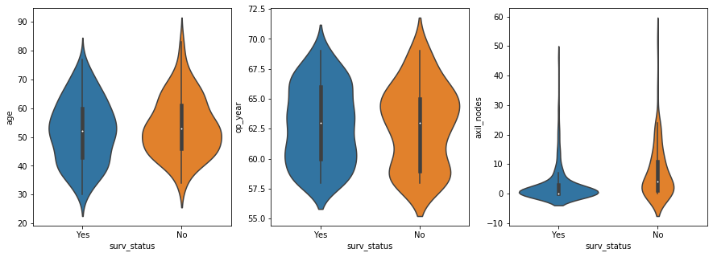

```python
fig, axes = plt.subplots(1, 3, figsize=(15, 5))
for idx, feature in enumerate(list(df.columns)[:-1]):
    sns.violinplot( x='surv_status', y=feature, data=df, ax=axes[idx])
plt.show()
```

- From year 1960 to 1962 , spread of patients surviving the operation was greater than patients not surving.
- The number of axillary nodes detected of the survivors is highly densed from 0 to 5.
- Almost 80% of the patients have less than or equal to 5 axillary nodes detected.

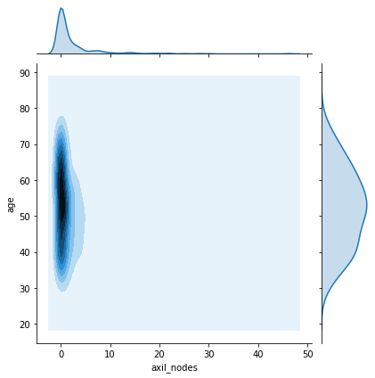

```python
sns.jointplot(x="axil_nodes", y="age", data=df_surv, kind="kde");
plt.show();
```

- Highest no. of patients who survived were having 0 Axillary nodes detected and were in the age range of 50 to 60.
- We can see that most of patients who survived had 0 Axillary nodes detected and maximum average Axillary nodes detected for patients were nearly 8 ( excluding outliers).

### Bivariate analysis

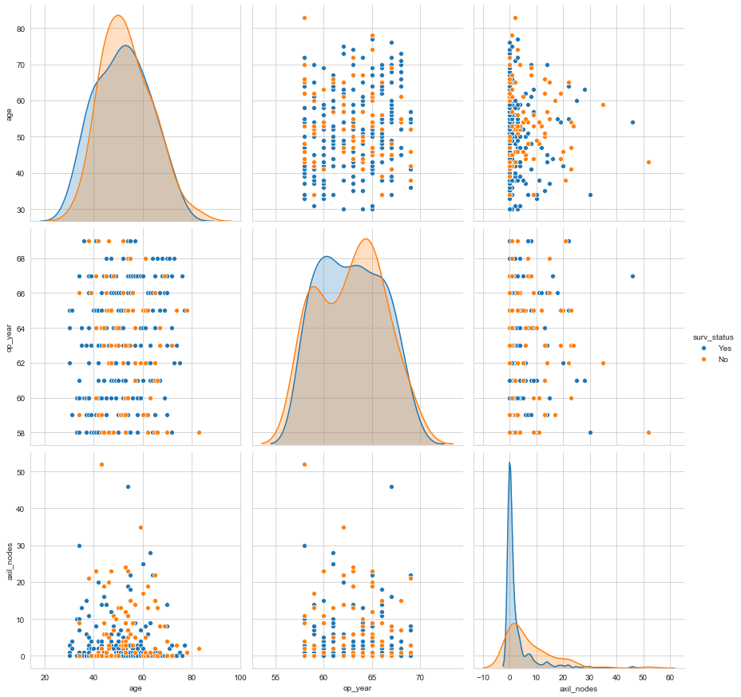

```python
# pairwise scatter plot: Pair-Plot
sns.set_style('whitegrid')
sns.pairplot(df,hue='surv_status',size=4)
plt.show()
```

- from "positive lymph node" vs "age" we can say that most of the people who survived had 0 positive lymph node
- For the feature Axillary nodes, we can observe that almost 90% of the patients who survived had less than 8 axillary nodes, while for those that did not survive the spread is wide.

## Conclusion:

1. The given dataset is imbalanced as each class doesnot have the equal no. of data points.
2. There is lot of overlapping of the data points, we can not classify / analyze data points using simple methologies.
3. Only Axillary nodes detected gives some intuition about the cases. If Axillary nodes detected is greater than 3, chances of surviving 5 years after operation is less, if it is less than 3 chances of survival is more.
4. As the no. of axillary nodes detected increase, chances of survival decrease.
5. Age and Operation Year had lot of overlappings, they are not useful for classifying the datapoints.